# All Blacks 2003-2018 Exploratory Data Analysis

Michele Zanatta

# Introduction

This is an Exploratory Data Analysis on the All Blacks Dataset I have found on Kaggle (https://www.kaggle.com/datasets/harryarthur/all-black-match-data20032018). The main objectives of this work is to gain some insights about the results All blacks have obtained during the period considered, using some of the classical EDA tools.

This is a work of my own. I choose the dataset, how to work and how much time to dedicate on it.

After uploading the library I used to get the job done, I have imported the dataset and applied basic preprocessing methodologies to getting to know the dataset. Then I have proceeded to work on the EDA, and at the very end I applied a t-test to see, in a very simplistic way, if the EDA was correct.

For any correction, suggestion and/or question please do not hesitate to contact me.

## Libraries

```r
library(dplyr)
library(tidyr)
library(ggplot2)
```

## Import Dataset

In this paragraph I just import the All Blacks dataset and look for some missing values or duplicates.

```r
AB <- read.csv('ABMatchData.csv', header = T)
head(AB)
```

|  | Opposition.Name | Date | Result | Location | Opposition.Debutants | Debutants | Opposition.tries.in.last.5.games | Tries.in.last.5.games | Opposition.Rating | Rating | Games.since.last.loss |
| --- | --- | --- | --- | --- | --- | --- | --- | --- | --- | --- | --- |
| 1 | Canada | 2003-10-17 | 62 | Melbourne | 0 | 1 | 9 | 28 | 65.62 | 89.80 | 8 |
| 2 | Tonga | 2003-10-24 | 84 | Brisbane | 1 | 1 | 13 | 31 | 70.08 | 89.80 | 9 |
| 3 | Wales | 2003-11-02 | 16 | Sydney | 0 | 0 | 17 | 37 | 76.92 | 89.80 | 10 |
| 4 | South Africa | 2003-11-08 | 20 | Melbourne | 0 | 0 | 28 | 44 | 81.84 | 89.80 | 11 |
| 5 | Australia | 2003-11-15 | -12 | Sydney | 0 | 0 | 41 | 45 | 86.20 | 90.41 | 12 |
| 6 | France | 2003-11-20 | 27 | Sydney | 0 | 0 | 21 | 35 | 84.66 | 88.17 | 1 |

```r
sum(is.na(AB))
```

```
## [1] 0
```

```r
sum(duplicated(AB))
```

```
## [1] 0
```

There are no NA values nor duplicates.

## Preprocessing

First of all I create new variables to better understanding the data we have. The variable WDL takes values 1 if the team considered has won, 0 if it has drawn and -1 if it has lost.

```r
AB <- AB %>% mutate(WDL = case_when(
    (Result > 0) ~ 1,
    (Result == 0) ~ 0,
    (Result < 0) ~ -1
    ));
```

The variable HA takes values 1 if the game was played at home and 0 if was played away. To do so we have to create a list of home stadium for the All Blacks. I do not make any distinction if the game was played in the opponent’s home field, or in a neutral location.

```r
locationAB <- unique(AB$Location)
locationAB
```

```
##  [1] "Melbourne"          "Brisbane"           "Sydney"
##  [4] "Dunedin"            "Auckland"           "Hamilton"
##  [7] "North Shore City"   "Wellington"         "Christchurch"
## [10] "Johannesburg"       "Rome"               "Millennium Stadium"
## [13] "Stade de France"    "Cape Town"          "Lansdowne Road"
## [16] "Twickenham"         "Murrayfield"        "Buenos Aires"
## [19] "Pretoria"           "Rustenberg"         "Lyon"
## [22] "Durban"             "Marseille"          "Toulouse"
## [25] "New Plymouth"       "Hong Kong"          "Croke Park"
## [28] "Bloemfontein"       "Tokyo"              "Milan"
## [31] "Port Elizabeth"     "La Plata"           "Napier"
## [34] "Chicago"            "Apia"               "Wembley"
## [37] "London"             "Newcastle"          "Nelson"
## [40] "Yokohama"
```

```r
ABHomeStadium <- list('Dunedin', 'Auckland', 'Hamilton', "North Shore City", "Wellington", "Christchurch", "New Plymouth", "Napier")

AB$HA <- ifelse(AB$Location %in% ABHomeStadium, 1, 0)
head(AB)
```

|  | Opposition.Name | Date | Result | Location | Opposition.Debutants | Debutants | Opposition.tries.in.last.5.games | Tries.in.last.5.games | Opposition.Rating | Rating | Games.since.last.loss | WDL | HA |
| --- | --- | --- | --- | --- | --- | --- | --- | --- | --- | --- | --- | --- | --- |
| 1 | Canada | 2003-10-17 | 62 | Melbourne | 0 | 1 | 9 | 28 | 65.62 | 89.80 | 8 | 1 | 0 |
| 2 | Tonga | 2003-10-24 | 84 | Brisbane | 1 | 1 | 13 | 31 | 70.08 | 89.80 | 9 | 1 | 0 |
| 3 | Wales | 2003-11-02 | 16 | Sydney | 0 | 0 | 17 | 37 | 76.92 | 89.80 | 10 | 1 | 0 |
| 4 | South Africa | 2003-11-08 | 20 | Melbourne | 0 | 0 | 28 | 44 | 81.84 | 89.80 | 11 | 1 | 0 |
| 5 | Australia | 2003-11-15 | -12 | Sydney | 0 | 0 | 41 | 45 | 86.20 | 90.41 | 12 | -1 | 0 |
| 6 | France | 2003-11-20 | 27 | Sydney | 0 | 0 | 21 | 35 | 84.66 | 88.17 | 1 | 1 | 0 |

Clear some variables

```r
rm(locationAB)
```

Another variable I want to create is a Year variable, which indicates the year the game was played, instead of the exact date.

```r
date <- AB$Date
AB <- AB %>% separate(Date, 'Year')
AB$Date <- date
head(AB)
```

|  | Opposition.Name | Year | Result | Location | Opposition.Debutants | Debutants | Opposition.tries.in.last.5.games | Tries.in.last.5.games | Opposition.Rating | Rating | Games.since.last.loss | WDL | HA | Date |
| --- | --- | --- | --- | --- | --- | --- | --- | --- | --- | --- | --- | --- | --- | --- |
| 1 | Canada | 2003 | 62 | Melbourne | 0 | 1 | 9 | 28 | 65.62 | 89.80 | 8 | 1 | 0 | 2003-10-17 |
| 2 | Tonga | 2003 | 84 | Brisbane | 1 | 1 | 13 | 31 | 70.08 | 89.80 | 9 | 1 | 0 | 2003-10-24 |
| 3 | Wales | 2003 | 16 | Sydney | 0 | 0 | 17 | 37 | 76.92 | 89.80 | 10 | 1 | 0 | 2003-11-02 |
| 4 | South Africa | 2003 | 20 | Melbourne | 0 | 0 | 28 | 44 | 81.84 | 89.80 | 11 | 1 | 0 | 2003-11-08 |
| 5 | Australia | 2003 | -12 | Sydney | 0 | 0 | 41 | 45 | 86.20 | 90.41 | 12 | -1 | 0 | 2003-11-15 |
| 6 | France | 2003 | 27 | Sydney | 0 | 0 | 21 | 35 | 84.66 | 88.17 | 1 | 1 | 0 | 2003-11-20 |

```r
rm(date)
```

Lastly, I want to create a variable which indicates if the game played was within the rugby World CUp, Three (then Four, or rugby Championship) Nations, Lions tour or a Test Match. To do so I will use the date column. I define the date vectors WC with the World Cup periods, CS indicating the championship periods and LT if the opponent were the Lions. If the game was not within these competitions, then I define it as Test Match (TM).

```r
WC <- c(c('2003-10-10', '2003-11-22'), c('2007-09-07', '2007-10-20'), c('2011-09-09', '2011-10-23'), c('2015-09-18', '2015-10-31'))
WC <- as.Date(WC)
mask <- rep(NA, length(AB$Date))

for (i in seq(1, length(WC), by = 2))
{
    mask <- ifelse((AB$Date > WC[i] & AB$Date < WC[i+1]) | mask == 'WC', 'WC', NA)
}

WC <- mask
rm(mask)

CS <- c('2003-07-12', '2003-08-16', '2004-07-17', '2004-08-21', '2005-07-30', '2005-09-03', '2006-07-08', '2006-09-06', '2007-06-16', '2007-07-21', '2008-07-08', '2008-08-02', '2009-07-18', '2009-09-19', '2010-07-10', '2010-09-11', '2011-07-23', '2011-08-27', '2012-08-18', '2012-10-06', '2013-08-17', '2013-10-05', '2014-08-16', '2014-10-05', '2015-07-17', '2015-08-08', '2016-08-20', '2016-10-08', '2017-08-19', '2017-10-07', '2018-08-18', '2018-10-06')

mask <- rep(NA, length(AB$Date))
CS <- as.Date(CS)
for (i in seq(1, length(CS), by = 2))
{
    mask <- ifelse((AB$Date >= CS[i] & AB$Date <= CS[i+1]) | mask == 'CS', 'CS', NA)
}
CS <- mask
rm(mask)

LT <- ifelse(AB$Opposition.Name == 'Lions', 'LT', NA)

Comp <- rep(NA, nrow(AB))

for (i in seq(1, nrow(AB)))
{
    if (!(is.na(WC[i])))
    {
        Comp[i] <- 'WC'
    }
    else if (!(is.na(LT[i])))
    {
        Comp[i] <- 'LT'
    }
    else if (!(is.na(CS[i])))
    {
        Comp[i] <- 'CS'
    }
    else
    {
        Comp[i] <- 'TM'
    }
}

AB$Competition <- Comp
```

Now I clear some variables that are not useful anymore.

```r
rm(Comp, CS, i, LT, WC, ABHomeStadium)
```

Finally, I transform numeric variables into factor variables.

```r
AB[sapply(AB, is.integer)] <- lapply(AB[sapply(AB, is.integer)], as.factor)
AB[sapply(AB, is.character)] <- lapply(AB[sapply(AB, is.character)], as.factor)

names <- c('Competition', 'HA', 'WDL')
AB[,names] <- lapply(AB[,names] , as.factor)
str(AB)
```

```
## 'data.frame':    205 obs. of  15 variables:
##  $ Opposition.Name                 : Factor w/ 21 levels "Argentina","Australia",..: 3 19 21 18 2 6 4 4 1 13 ...
##  $ Year                            : Factor w/ 16 levels "2003","2004",..: 1 1 1 1 1 1 2 2 2 2 ...
##  $ Result                          : Factor w/ 74 levels "-17","-15","-14",..: 64 71 31 35 5 42 48 39 49 30 ...
##  $ Location                        : Factor w/ 40 levels "Apia","Auckland",..: 20 4 34 20 34 34 10 2 12 28 ...
##  $ Opposition.Debutants            : Factor w/ 8 levels "0","1","2","3",..: 1 2 1 1 1 1 2 3 2 3 ...
##  $ Debutants                       : Factor w/ 8 levels "0","1","2","3",..: 2 2 1 1 1 1 4 2 2 2 ...
##  $ Opposition.tries.in.last.5.games: Factor w/ 30 levels "2","3","4","5",..: 8 12 16 27 29 20 16 9 30 1 ...
##  $ Tries.in.last.5.games           : Factor w/ 37 levels "6","7","8","9",..: 23 26 31 34 35 30 26 16 13 15 ...
##  $ Opposition.Rating               : num  65.6 70.1 76.9 81.8 86.2 ...
##  $ Rating                          : num  89.8 89.8 89.8 89.8 90.4 ...
##  $ Games.since.last.loss           : Factor w/ 23 levels "1","2","3","4",..: 8 9 10 11 12 1 2 3 4 5 ...
##  $ WDL                             : Factor w/ 3 levels "-1","0","1": 3 3 3 3 1 3 3 3 3 3 ...
##  $ HA                              : Factor w/ 2 levels "0","1": 1 1 1 1 1 1 2 2 2 2 ...
##  $ Date                            : Factor w/ 205 levels "2003-10-17","2003-10-24",..: 1 2 3 4 5 6 7 8 9 10 ...
##  $ Competition                     : Factor w/ 4 levels "CS","LT","TM",..: 4 4 4 4 4 4 3 3 3 3 ...
```

```r
rm(names)
```

## Exploratory Data Analysis

To start my EDA, I asked myself different question I would like to answer.

The questions are the following: - Is playing at home an advantage for the team? - Which are the best and worst years? - Does the ratings of the opponent have some influence on the result? - Debutants are correlated with the result of the game? - Does something change with regard to the competition the team is playing?

### Home or Away?

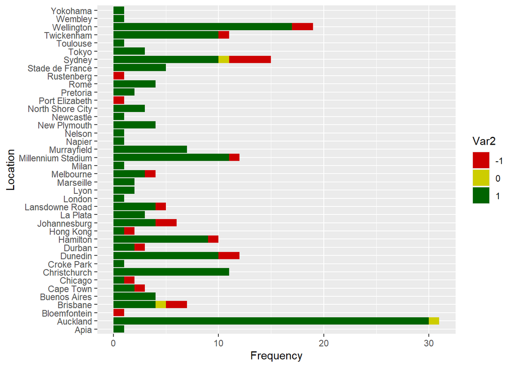

```r
table.location <- data.frame(table(AB$Location, AB$WDL))
plot.location <- table.location %>% ggplot(aes(x = Var1, y = Freq, fill = Var2)) +
  scale_fill_manual(values = c('red3', 'yellow3', 'darkgreen')) +
  geom_bar(stat = 'identity') +
  coord_flip() +
  labs(x = 'Location', y = 'Frequency')
plot.location
```

We can see from this bar plot that Auckland is the best place to play for the All Blacks as they have never lost a match there, while the worse is Sidney with just two wins out of three matches played in proportion. Johannesburg and Brisbane, also, are tough fields for New Zealand, but there have been less game played there. Proceeding in this direction, we now observe the percentage of victories for each stadium. Note that there are various fields where All Blacks played just once, and therefore they have 100% or 0% of wins but we will consider them.

```r
options(digits=2)

table.WDL <- table(AB$WDL)
df.WDL <- data.frame(prop.table(table.WDL))
colnames(df.WDL) <- c('WDL', 'Freq')
df.WDL
```

| WDL | Freq |
| --- | --- |
| -1 | 0.117 |
| 0 | 0.015 |
| 1 | 0.868 |

```r
AB.Location.WDL <- AB %>% group_by(Location)
AB.Location.WDL <- AB.Location.WDL %>% summarise(Total = n(), win = sum(WDL == 1), draw = sum(WDL == 0), lost = sum(WDL == -1), Win_Perc = win/Total)

AB.Location.WDL <- AB.Location.WDL[order(-AB.Location.WDL$Total, AB.Location.WDL$Win_Perc),]

AB.Location.WDL
```

| Location | Total | win | draw | lost | Win_Perc |
| --- | --- | --- | --- | --- | --- |
| Auckland | 31 | 30 | 1 | 0 | 0.97 |
| Wellington | 19 | 17 | 0 | 2 | 0.89 |
| Sydney | 15 | 10 | 1 | 4 | 0.67 |
| Dunedin | 12 | 10 | 0 | 2 | 0.83 |
| Millennium Stadium | 12 | 11 | 0 | 1 | 0.92 |
| Twickenham | 11 | 10 | 0 | 1 | 0.91 |
| Christchurch | 11 | 11 | 0 | 0 | 1.00 |
| Hamilton | 10 | 9 | 0 | 1 | 0.90 |
| Brisbane | 7 | 4 | 1 | 2 | 0.57 |
| Murrayfield | 7 | 7 | 0 | 0 | 1.00 |

[output cut: 30 more lines]

Auckland is confirmed to be the best place to play, followed by Wellington and Cristchurch in the New Zealand territory. Outside it, the All Blacks have a good record in Wales (Millenium Stadium) and England (Twickenham), with just one game lost in the period considered.

Now we look at the difference between games played at home and away.

```r
AB.HA <- AB %>% group_by(HA)
AB.HA <- AB.HA %>% summarise(Total = n(), win = sum(WDL == 1), draw = sum(WDL == 0), lost = sum(WDL == -1), Win_Perc = win/Total)
AB.HA
```

| HA | Total | win | draw | lost | Win_Perc |
| --- | --- | --- | --- | --- | --- |
| 0 | 114 | 93 | 2 | 19 | 0.82 |
| 1 | 91 | 85 | 1 | 5 | 0.93 |

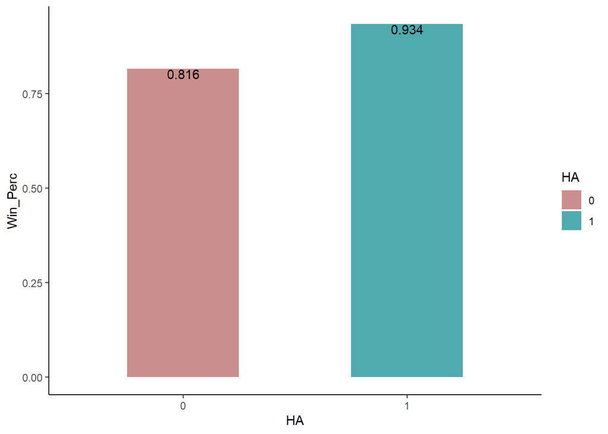

```r
plot.HA <- ggplot(AB.HA, aes(x = HA, y = Win_Perc, fill = HA)) +
  geom_bar(stat = 'identity', width = 0.5) +
  scale_fill_hue(c = 40) +
  geom_text(aes(label = round(Win_Perc, 3)), vjust = 1) +
  theme_classic()

plot.HA
```

So there is a gap between the games played at home and the games played away. We continue our analysis looking for the average result in both the home and away game through a boxplot.

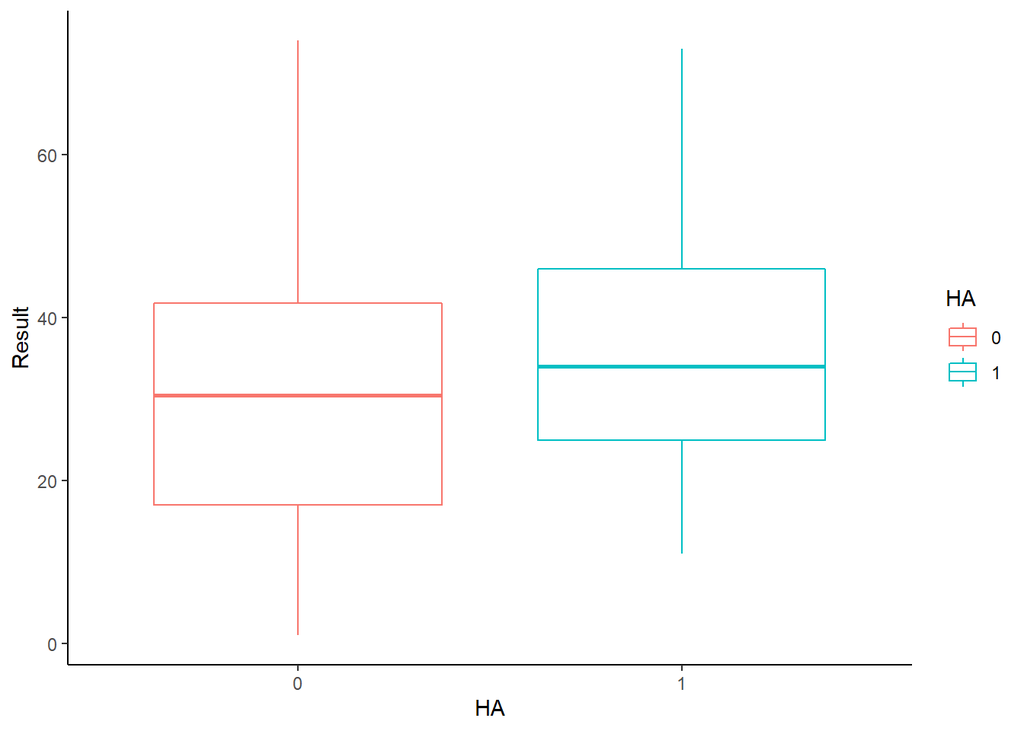

```r
AB %>% ggplot(aes(x = HA, y = as.numeric(Result), col = HA)) +
  geom_boxplot() +
  ylab('Result') +
  theme_classic()
```

Thus, it seems clear that playing at home represents an advantage for the All Blacks. To conclude, we look at the different rating for game played at home or away. It could be that All blacks play at home weaker teams, and this end up in the difference we see on the previous graphs.

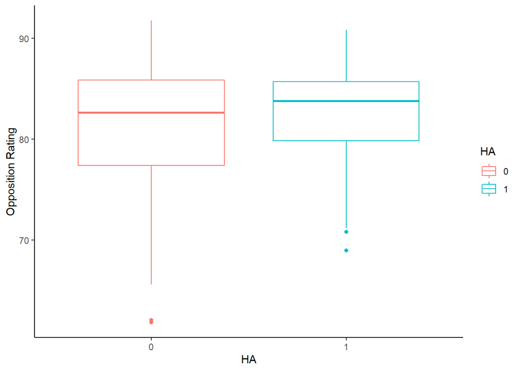

```r
AB %>% ggplot(aes(x = HA, y = as.numeric(Opposition.Rating), col = HA)) +
  geom_boxplot() +
  ylab('Opposition Rating') +
  theme_classic()
```

Thus, we can see that despite playing teams with higher rating on average (and median), the All Black still have a better record at home, meaning that playing at home is a huge advantage for them.

### Which year?

I will try to understand in which year the All Blacks had the best team, obtaining the best results overall, and in which year they have the worst.

```r
AB.Year <- AB %>% group_by(Year)

AB.Year <- AB.Year %>% summarise(Total = n(), win = sum(WDL == 1), draw = sum(WDL == 0), lost = sum(WDL == -1), Win_Perc = win/Total, avg_rating = median(Opposition.Rating), max_rating = max(Opposition.Rating), min_rating = min(Opposition.Rating), home = sum(as.numeric(HA)-1))

AB.Year <- AB.Year[order(-AB.Year$Total, AB.Year$Win_Perc),]
AB.Year
```

| Year | Total | win | draw | lost | Win_Perc | avg_rating | max_rating | min_rating | home |
| --- | --- | --- | --- | --- | --- | --- | --- | --- | --- |
| 2008 | 15 | 13 | 0 | 2 | 0.87 | 83 | 91 | 73 | 7 |
| 2009 | 14 | 10 | 0 | 4 | 0.71 | 84 | 90 | 71 | 6 |
| 2017 | 14 | 11 | 1 | 2 | 0.79 | 84 | 86 | 71 | 7 |
| 2012 | 14 | 12 | 1 | 1 | 0.86 | 80 | 87 | 77 | 6 |
| 2014 | 14 | 12 | 1 | 1 | 0.86 | 86 | 89 | 67 | 6 |
| 2018 | 14 | 12 | 0 | 2 | 0.86 | 80 | 90 | 73 | 5 |
| 2010 | 14 | 13 | 0 | 1 | 0.93 | 84 | 89 | 77 | 6 |
| 2016 | 14 | 13 | 0 | 1 | 0.93 | 82 | 85 | 72 | 7 |
| 2013 | 14 | 14 | 0 | 0 | 1.00 | 82 | 89 | 72 | 7 |
| 2006 | 13 | 12 | 0 | 1 | 0.92 | 85 | 88 | 77 | 5 |

[output cut: 6 more lines]

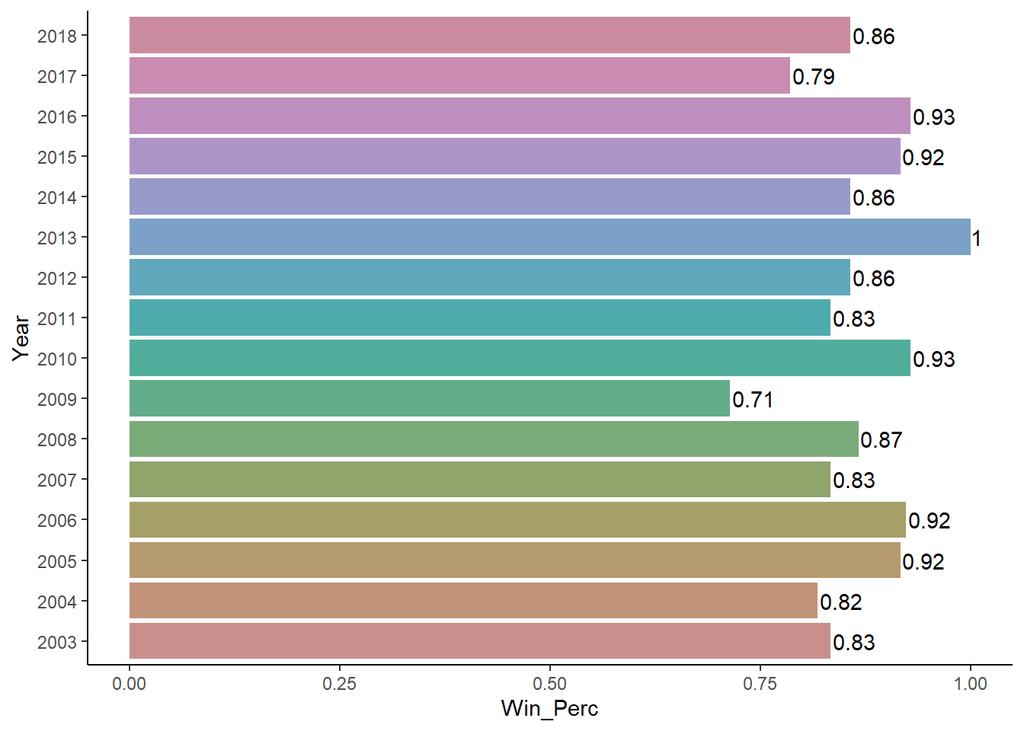

```r
AB.Year %>% ggplot(aes(x = Win_Perc, y = Year, fill = Year)) +
  geom_bar(stat = 'identity', show.legend = FALSE) +
  scale_fill_hue(c = 40) +
  geom_text(aes(label = round(Win_Perc, 2), hjust = -0.05)) +
  theme_classic()
```

It is easy to note that the best year has been the 2013, with 14 wins and zero losses. It is equally easy to see that the worst year has been the 2009, with a total of 4 losses, number that we do not find in any other year. The opposition ratings in these year are quite similar so it does not depend on them. We look closely to these years.

```r
AB.Worst.Year <- AB[AB$Year == 2009,]
AB.Worst.Year
```

|  | Opposition.Name | Year | Result | Location | Opposition.Debutants | Debutants | Opposition.tries.in.last.5.games | Tries.in.last.5.games | Opposition.Rating | Rating | Games.since.last.loss | WDL | HA | Date | Competition |
| --- | --- | --- | --- | --- | --- | --- | --- | --- | --- | --- | --- | --- | --- | --- | --- |
| 70 | France | 2009 | -5 | Dunedin | 2 | 3 | 14 | 14 | 80 | 93 | 10 | -1 | 1 | 2009-06-13 | TM |
| 71 | France | 2009 | 4 | Wellington | 0 | 0 | 15 | 14 | 82 | 91 | 1 | 1 | 1 | 2009-06-20 | TM |
| 72 | Italy | 2009 | 21 | Christchurch | 0 | 5 | 2 | 11 | 71 | 91 | 2 | 1 | 1 | 2009-06-27 | TM |
| 73 | Australia | 2009 | 6 | Auckland | 1 | 0 | 15 | 11 | 86 | 91 | 3 | 1 | 1 | 2009-07-18 | CS |
| 74 | South Africa | 2009 | -9 | Bloemfontein | 0 | 0 | 11 | 10 | 89 | 91 | 4 | -1 | 0 | 2009-07-25 | CS |
| 75 | South Africa | 2009 | -12 | Durban | 0 | 0 | 12 | 8 | 90 | 90 | 1 | -1 | 0 | 2009-08-01 | CS |
| 76 | Australia | 2009 | 1 | Sydney | 0 | 0 | 14 | 7 | 86 | 89 | 1 | 1 | 0 | 2009-08-22 | CS |
| 77 | South Africa | 2009 | -3 | Hamilton | 0 | 0 | 8 | 7 | 90 | 90 | 2 | -1 | 1 | 2009-09-12 | CS |
| 78 | Australia | 2009 | 27 | Wellington | 0 | 1 | 8 | 6 | 86 | 89 | 1 | 1 | 1 | 2009-09-19 | CS |
| 79 | Australia | 2009 | 13 | Tokyo | 0 | 0 | 7 | 8 | 85 | 90 | 2 | 1 | 0 | 2009-10-31 | TM |

[output cut: 4 more lines]

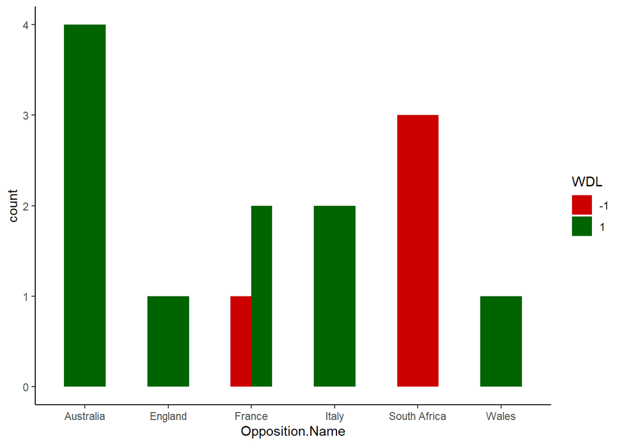

```r
AB.Worst.Year %>% ggplot(aes(x = Opposition.Name, fill = WDL)) +
  geom_bar(stat = 'count', position = 'dodge', width = 0.5) +
  scale_fill_manual(values = c('red3', 'darkgreen')) +
  theme_classic()
```

```r
AB.Worst.Year <- AB.Worst.Year %>% group_by(Opposition.Name)
AB.Worst.Year <- AB.Worst.Year %>% summarize(win = sum(WDL == 1), draw = sum(WDL == 0), loss = sum(WDL == -1), avg_rating = mean(Opposition.Rating), n_debutants = sum(as.numeric(Debutants)))
AB.Worst.Year
```

| Opposition.Name | win | draw | loss | avg_rating | n_debutants |
| --- | --- | --- | --- | --- | --- |
| Australia | 4 | 0 | 0 | 86 | 5 |
| England | 1 | 0 | 0 | 81 | 1 |
| France | 2 | 0 | 1 | 82 | 6 |
| Italy | 2 | 0 | 0 | 71 | 10 |
| South Africa | 0 | 0 | 3 | 90 | 3 |
| Wales | 1 | 0 | 0 | 81 | 2 |

```r
#################################################################################

AB.Best.Year <- AB[AB$Year == 2013,]
AB.Best.Year
```

|  | Opposition.Name | Year | Result | Location | Opposition.Debutants | Debutants | Opposition.tries.in.last.5.games | Tries.in.last.5.games | Opposition.Rating | Rating | Games.since.last.loss | WDL | HA | Date | Competition |
| --- | --- | --- | --- | --- | --- | --- | --- | --- | --- | --- | --- | --- | --- | --- | --- |
| 124 | France | 2013 | 10 | Auckland | 4 | 1 | 6 | 17 | 82 | 90 | 1 | 1 | 1 | 2013-06-08 | TM |
| 125 | France | 2013 | 30 | Christchurch | 2 | 1 | 5 | 19 | 82 | 90 | 2 | 1 | 1 | 2013-06-15 | TM |
| 126 | France | 2013 | 15 | New Plymouth | 1 | 3 | 5 | 16 | 82 | 90 | 3 | 1 | 1 | 2013-06-22 | TM |
| 127 | Australia | 2013 | 18 | Sydney | 5 | 1 | 6 | 13 | 87 | 90 | 4 | 1 | 0 | 2013-08-17 | CS |
| 128 | Australia | 2013 | 11 | Wellington | 0 | 1 | 7 | 16 | 85 | 92 | 5 | 1 | 1 | 2013-08-24 | CS |
| 129 | Argentina | 2013 | 15 | Hamilton | 0 | 1 | 6 | 15 | 76 | 92 | 6 | 1 | 1 | 2013-09-07 | CS |
| 130 | South Africa | 2013 | 14 | Auckland | 0 | 0 | 25 | 16 | 89 | 92 | 7 | 1 | 1 | 2013-09-14 | CS |
| 131 | Argentina | 2013 | 18 | La Plata | 0 | 0 | 6 | 17 | 76 | 92 | 8 | 1 | 0 | 2013-09-28 | CS |
| 132 | South Africa | 2013 | 11 | Johannesburg | 1 | 0 | 19 | 19 | 89 | 92 | 9 | 1 | 0 | 2013-10-05 | CS |
| 133 | Australia | 2013 | 8 | Dunedin | 1 | 0 | 10 | 18 | 84 | 93 | 10 | 1 | 1 | 2013-10-19 | TM |

[output cut: 4 more lines]

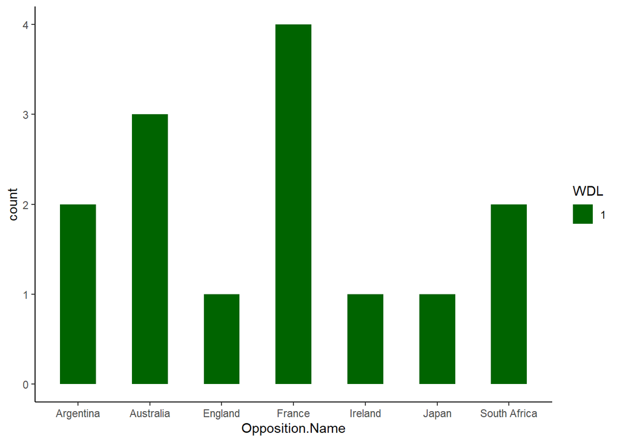

```r
AB.Best.Year %>% ggplot(aes(x = Opposition.Name, fill = WDL)) +
  geom_bar(stat = 'count', position = 'dodge', width = 0.5) +
  scale_fill_manual(values = c('darkgreen')) +
  theme_classic()
```

```r
AB.Best.Year <- AB.Best.Year %>% group_by(Opposition.Name)
AB.Best.Year <- AB.Best.Year %>% summarize(win = sum(WDL == 1), draw = sum(WDL == 0), loss = sum(WDL == -1), avg_rating = mean(Opposition.Rating), n_debutants = sum(as.numeric(as.character(Debutants))))
AB.Best.Year
```

| Opposition.Name | win | draw | loss | avg_rating | n_debutants |
| --- | --- | --- | --- | --- | --- |
| Argentina | 2 | 0 | 0 | 76 | 1 |
| Australia | 3 | 0 | 0 | 86 | 2 |
| England | 1 | 0 | 0 | 86 | 0 |
| France | 4 | 0 | 0 | 82 | 5 |
| Ireland | 1 | 0 | 0 | 79 | 0 |
| Japan | 1 | 0 | 0 | 72 | 3 |
| South Africa | 2 | 0 | 0 | 89 | 0 |

### Opposition Ratings

We continue our analysis looking for the influence on the opposition rating. First of all we create 5 different classes to describe the opposition strength based on the opposition rating.

```r
AB$Opposition.Class <- cut(AB$Opposition.Rating, breaks = 5, labels = 1:5)
head(AB)
```

|  | Opposition.Name | Year | Result | Location | Opposition.Debutants | Debutants | Opposition.tries.in.last.5.games | Tries.in.last.5.games | Opposition.Rating | Rating | Games.since.last.loss | WDL | HA | Date | Competition | Opposition.Class |
| --- | --- | --- | --- | --- | --- | --- | --- | --- | --- | --- | --- | --- | --- | --- | --- | --- |
| 1 | Canada | 2003 | 62 | Melbourne | 0 | 1 | 9 | 28 | 66 | 90 | 8 | 1 | 0 | 2003-10-17 | WC | 1 |
| 2 | Tonga | 2003 | 84 | Brisbane | 1 | 1 | 13 | 31 | 70 | 90 | 9 | 1 | 0 | 2003-10-24 | WC | 2 |
| 3 | Wales | 2003 | 16 | Sydney | 0 | 0 | 17 | 37 | 77 | 90 | 10 | 1 | 0 | 2003-11-02 | WC | 3 |
| 4 | South Africa | 2003 | 20 | Melbourne | 0 | 0 | 28 | 44 | 82 | 90 | 11 | 1 | 0 | 2003-11-08 | WC | 4 |
| 5 | Australia | 2003 | -12 | Sydney | 0 | 0 | 41 | 45 | 86 | 90 | 12 | -1 | 0 | 2003-11-15 | WC | 5 |
| 6 | France | 2003 | 27 | Sydney | 0 | 0 | 21 | 35 | 85 | 88 | 1 | 1 | 0 | 2003-11-20 | WC | 4 |

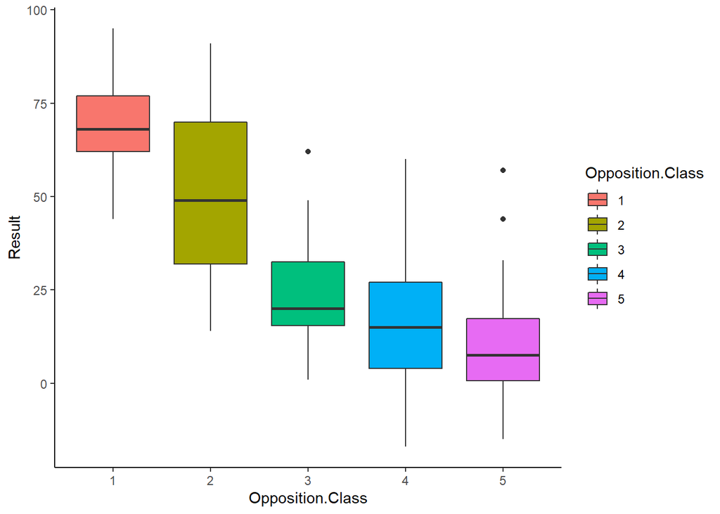

```r
AB %>% ggplot(aes(x = Opposition.Class, y = as.numeric(as.character(Result)), fill = Opposition.Class)) +
  geom_boxplot() +
  ylab('Result') +
  theme_classic()
```

```r
AB.Opposition.Rating <- AB %>% group_by(Opposition.Class)
AB.Opposition.Rating <- AB.Opposition.Rating %>% summarise(Total = n(), win = sum(WDL == 1), draw = sum(WDL == 0), loss = sum(WDL == -1), Win_Perc = win/Total, n_debutants = sum(as.numeric(as.character(Debutants))))
AB.Opposition.Rating
```

| Opposition.Class | Total | win | draw | loss | Win_Perc | n_debutants |
| --- | --- | --- | --- | --- | --- | --- |
| 1 | 5 | 5 | 0 | 0 | 1.00 | 2 |
| 2 | 19 | 19 | 0 | 0 | 1.00 | 29 |
| 3 | 39 | 39 | 0 | 0 | 1.00 | 39 |
| 4 | 90 | 76 | 1 | 13 | 0.84 | 59 |
| 5 | 52 | 39 | 2 | 11 | 0.75 | 10 |

Thus the opposition class has a huge influence on the result of the game, as it was easily predictable. From the table we can see that All Blacks never suffered a loss against a team in the class 3 or below, while the percentage of win decrease against team with rating over 86. Still, the arithmetic mean and median are positive over all the classes with notable outliers against team belonging to class 5.

```r
AB %>% select(c('Opposition.Name', 'Year', 'Result', 'Opposition.Rating', 'Competition', 'Location', 'HA')) %>%  filter(as.numeric(as.character(AB$Result)) > quantile(as.numeric(as.character(AB$Result)))[4] & AB$Opposition.Class == 5)
```

| Opposition.Name | Year | Result | Opposition.Rating | Competition | Location | HA |
| --- | --- | --- | --- | --- | --- | --- |
| England | 2004 | 33 | 91 | TM | Dunedin | 1 |
| France | 2006 | 44 | 88 | TM | Lyon | 0 |
| Australia | 2014 | 31 | 87 | CS | Auckland | 1 |
| South Africa | 2017 | 57 | 86 | CS | North Shore City | 1 |

### Shall we play debutantes

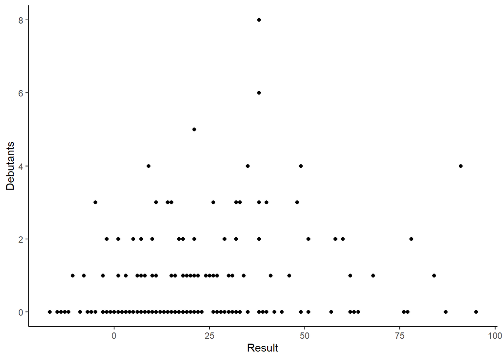

```r
AB %>% ggplot(aes(x = as.numeric(as.character(Result)), y = as.numeric(as.character(Debutants)))) +
  geom_point() +
  xlab('Result') +
  ylab('Debutants') +
  theme_classic()
```

```r
table(AB$Debutants)
```

```
##
##   0   1   2   3   4   5   6   8
## 130  42  16  10   4   1   1   1
```

```r
AB$Bin.Debutants <- if_else(as.numeric(as.character(AB$Debutants)) > 0, 1, 0)
table(AB$Bin.Debutants)
```

```
##
##   0   1
## 130  75
```

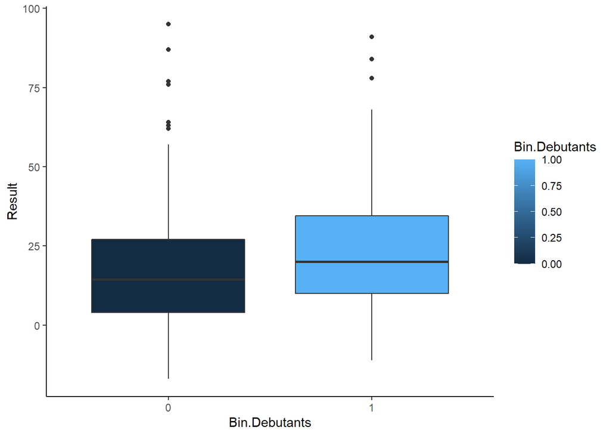

```r
AB %>% ggplot(aes(x = as.factor(Bin.Debutants), y = as.numeric(as.character(Result)), fill = Bin.Debutants)) +
  geom_boxplot() +
  ylab('Result') +
  xlab('Bin.Debutants') +
  theme_classic()
```

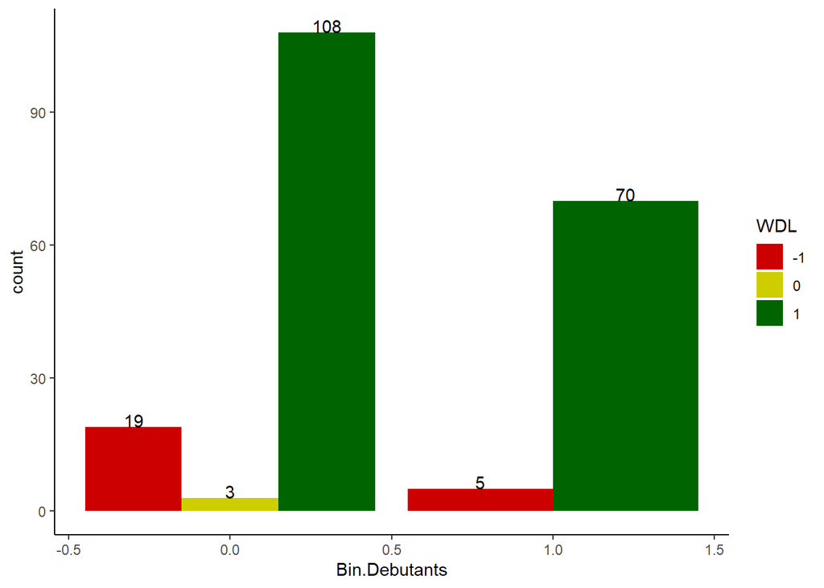

```r
AB %>% ggplot(aes(x = Bin.Debutants, fill = WDL)) +
  geom_bar(position = 'dodge') +
  scale_fill_manual(values = c('red3', 'yellow3', 'darkgreen')) +
  geom_text(aes(label = ..count..), stat = "count", colour = "black", position = position_dodge(.9), vjust = 0) +
  xlab('Bin.Debutants') +
  theme_classic()
```

It seem that playing debutants is helping the team having better result. I would like to see, now, if this is effectively because of that or there is another reason behind.

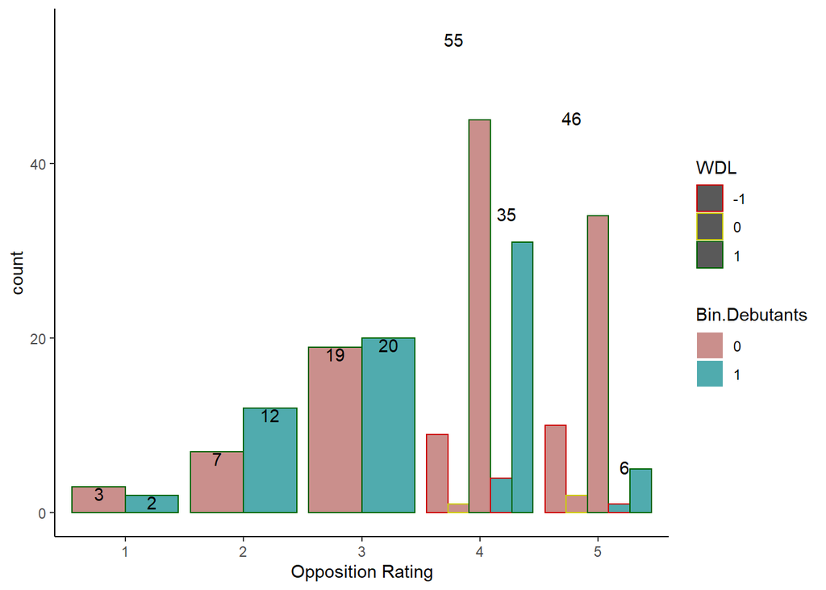

```r
AB %>% ggplot(aes(x = Opposition.Class, fill = as.factor(Bin.Debutants), color = WDL)) +
  geom_bar(position = 'dodge') +
  xlab('Opposition Rating') +
  ylab('count') +
  labs(fill = "Bin.Debutants") +
  scale_fill_hue(c = 40) +
  scale_color_manual(values = c('red3', 'yellow3', 'darkgreen')) +
  geom_text(aes(label = ..count.., vjust = 1), stat = 'count',position = position_dodge(0.9), color = 'black') +
  theme_classic()
```

As predicted, All Blacks seems to have better results playing debutantes just because they introduce more players while playing with team of lower rating. Just 6 out of 52 games with a team of class 5 had some debutantes playing.

### Competition

```r
AB.Competition <- AB %>% group_by(Competition)
AB.Competition <- AB.Competition %>% summarise(Total = n(), win = sum(WDL == 1), draw = sum(WDL == 0), loss = sum(WDL == -1), win_perc = win/Total, avg_rating = mean(Opposition.Rating), median_rating = median(Opposition.Rating))
AB.Competition
```

| Competition | Total | win | draw | loss | win_perc | avg_rating | median_rating |
| --- | --- | --- | --- | --- | --- | --- | --- |
| CS | 77 | 61 | 1 | 15 | 0.79 | 85 | 86 |
| LT | 6 | 4 | 1 | 1 | 0.67 | 83 | 83 |
| TM | 100 | 93 | 1 | 6 | 0.93 | 81 | 81 |
| WC | 22 | 20 | 0 | 2 | 0.91 | 76 | 76 |

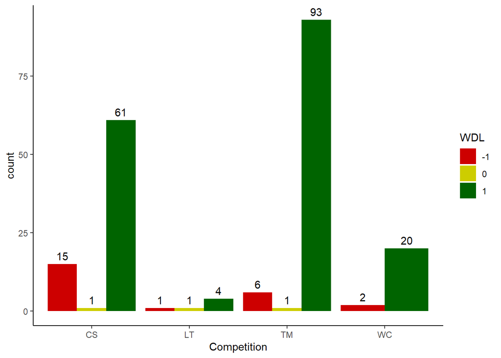

```r
AB %>% ggplot(aes(x = Competition, fill = WDL)) +
  geom_bar(position = 'dodge') +
  scale_fill_manual(values = c('red3', 'yellow3', 'darkgreen')) +
  geom_text(aes(label = ..count.., vjust = -0.5), position = position_dodge(.9), stat = 'count') +
  theme_classic()
```

The All Blacks have the lowest percentage win when playing the Lions Tour, even if is has to be considered that there have been just 6 games between them. Except that, we can see that they have suffered the most losses playing in the Championship, where the average rating of the opponents is the highest spread on all the competitions.

```r
AB %>% select(c('Opposition.Name', 'Result', 'Year', 'Opposition.Rating', 'Competition', 'Location')) %>%
  filter(AB$WDL != 1) %>% arrange(Competition)
```

| Opposition.Name | Result | Year | Opposition.Rating | Competition | Location |
| --- | --- | --- | --- | --- | --- |
| Australia | -5 | 2004 | 88 | CS | Sydney |
| South Africa | -14 | 2004 | 83 | CS | Johannesburg |
| South Africa | -6 | 2005 | 87 | CS | Cape Town |
| South Africa | -1 | 2006 | 85 | CS | Rustenberg |
| Australia | -5 | 2007 | 85 | CS | Melbourne |
| South Africa | -2 | 2008 | 90 | CS | Dunedin |
| Australia | -15 | 2008 | 86 | CS | Sydney |
| South Africa | -9 | 2009 | 89 | CS | Bloemfontein |
| South Africa | -12 | 2009 | 90 | CS | Durban |
| South Africa | -3 | 2009 | 90 | CS | Hamilton |

[output cut: 17 more lines]

We can then say that it is not the competition that influence the result of a game, as it intrinsically contain the information of the opposition rating.

```r
l = ls()
l <- l[2:length(l)]
rm(list = l)
rm(l)
```

We conclude this section saying that basically, what we obtained from the EDA is that the factor which more influences the result of a game is the opposition rating and the location of the game. A very simplistic way to verify this is to applying a t-test on the result based on the opposition rating and observing the p-value. A more challenging way is to build a statistical model which can give us more insights, but I will not get into that in this report.

# t-Test

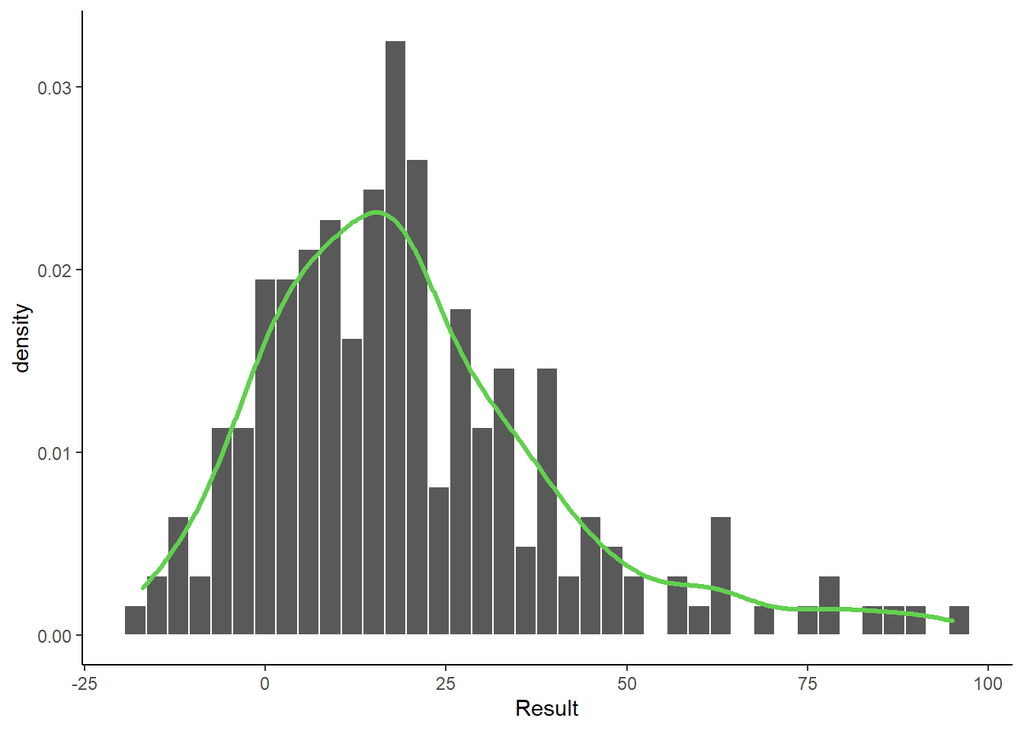

```r
AB %>% ggplot(aes(x = as.numeric(as.character(Result)))) +
  geom_histogram(aes(y = ..density..), col = 'white', binwidth = 3) +
  xlab('Result') +
  geom_density(lwd = 1.2, linetype = 1, colour = 3) +
  theme_classic()
```

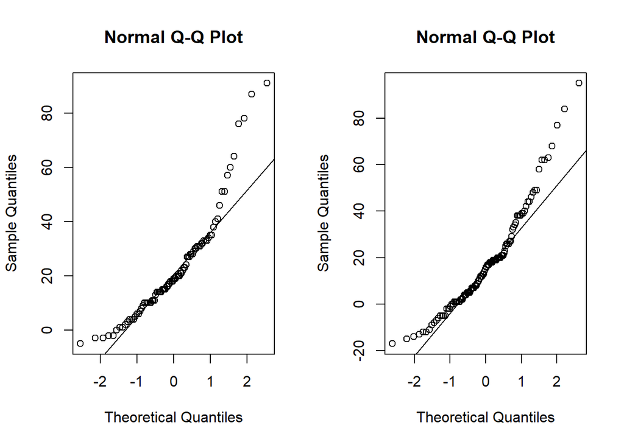

```r
par(mfrow=c(1, 2))
qqnorm(as.numeric(as.character(AB[AB$HA == 1, 'Result'])))
qqline(as.numeric(as.character(AB[AB$HA == 1, 'Result'])))
qqnorm(as.numeric(as.character(AB[AB$HA == 0, 'Result'])))
qqline(as.numeric(as.character(AB[AB$HA == 0, 'Result'])))
```

```r
par(mfrow=c(1, 1))

t.test(as.numeric(as.character(AB[AB$HA == 0, 'Result'])), as.numeric(as.character(AB[AB$HA == 1, 'Result'])), alternative = 'two.sided')
```

```
##
##  Welch Two Sample t-test
##
## data:  as.numeric(as.character(AB[AB$HA == 0, "Result"])) and as.numeric(as.character(AB[AB$HA == 1, "Result"]))
## t = -2, df = 200, p-value = 0.09
## alternative hypothesis: true difference in means is not equal to 0
## 95 percent confidence interval:
##  -10.62   0.72
## sample estimates:
## mean of x mean of y
##        18        23
```

```r
t.test(as.numeric(as.character(AB[as.numeric(as.character(AB$Opposition.Class)) < 4, 'Result'])), as.numeric(as.character(AB[as.numeric(as.character(AB$Opposition.Class)) >= 4, 'Result'])), alternative = 'two.sided')
```

```
##
##  Welch Two Sample t-test
##
## data:  as.numeric(as.character(AB[as.numeric(as.character(AB$Opposition.Class)) < 4, "Result"])) and as.numeric(as.character(AB[as.numeric(as.character(AB$Opposition.Class)) >= 4, "Result"]))
## t = 7, df = 85, p-value = 3e-09
## alternative hypothesis: true difference in means is not equal to 0
## 95 percent confidence interval:
##  15 28
## sample estimates:
## mean of x mean of y
##        35        13
```

We observe that the p-value for the second test is very small, meaning that the opposition rating has a huge influence on the result of a match. On the other hand, there is no significant proof that the location of a game affects the game.

# Conclusion

This report is not intended to be formal or shown during a presentation, but it is a fun way to dive into the EDA.

The results I have obtained are not surprising, since I have end up saying that what determine more the result of a game between All blacks and opponent is the rating of the opponent.